# Assignment 3: Dynamic Reports

Pierre Wensel

09 November, 2023

# 1 Introduction, Data Importation, Visualization, and Factorization

This is an R Markdown document used to generate a corresponding html file. Markdown is a simple formatting syntax for authoring HTML, PDF, and MS Word documents. This report was created to summarize work performed to obtain and summarize information in the dataset obtained from a file entitled **“SNPdataset.txt”** that includes the following:

*1. The proportion of cases and controls*

*2. The proportion of women and men.*

*3. The proportion of women and men within cases and controls, respectively.*

*4. The distribution of the genotypes for each specific SNP when stratifying by sex and by case/control.*

*5. Displayed basic plots summarizing the aforementioned information.*

In general, for categorical variables like GENDER and CASECONTROL or a numerical variable with few different values, numerical summaries and associated barplots for GENDER, CASECONTROL, and SNP[1-5] were generated:

The file dataset SNPdataset.txt was loaded into a dataframe snpdata as follows:

```r
snpdata <- read.table("SNPdataset.txt", header=T, sep="")
```

The dataframe was then visualized as follows:

```r
head(snpdata)
```

```
##   CASECONTROL SNP1 SNP2 SNP3 SNP4 SNP5 GENE_EXPRESSION AGE GENDER
## 1           1   TT   GG   AA   AA   CC        75640.52  43 Female
## 2           1   TT   CG   AA   AC   AC        28688.22  45 Female
## 3           1   TT   GG   AA   CC   CC        17279.59  47 Female
## 4           1   CT   GG   AA   AC   CC        27253.99  35   Male
## 5           1   TT   GG   AA   AC   AC        38066.57  38 Female
## 6           1   TT   GG   AA   AA   CC         9872.46  32 Female
```

The dataframe was then visualized alternatively as follows:

```r
summary(snpdata)
```

```
##   CASECONTROL         SNP1               SNP2               SNP3
##  Min.   :0.0000   Length:157         Length:157         Length:157
##  1st Qu.:0.0000   Class :character   Class :character   Class :character
##  Median :1.0000   Mode  :character   Mode  :character   Mode  :character
##  Mean   :0.7006
##  3rd Qu.:1.0000
##  Max.   :1.0000
##      SNP4               SNP5           GENE_EXPRESSION       AGE
##  Length:157         Length:157         Min.   :  1615   Min.   :26.00
##  Class :character   Class :character   1st Qu.: 25601   1st Qu.:36.00
##  Mode  :character   Mode  :character   Median : 38333   Median :41.00
##                                        Mean   : 43044   Mean   :40.52
##                                        3rd Qu.: 61252   3rd Qu.:45.00
##                                        Max.   :123334   Max.   :59.00
##     GENDER
##  Length:157
##  Class :character
##  Mode  :character
##
##
##
```

The dataframe was then visualized alternatively as follows using Kable:

```r
kable(snpdata, caption = "Classic Kable Style For SNPData.txt data") %>%
  kable_classic(full_width = F, html_font = "Cambria")
```

Classic Kable Style For SNPData.txt data

| CASECONTROL | SNP1 | SNP2 | SNP3 | SNP4 | SNP5 | GENE_EXPRESSION | AGE | GENDER |
| --- | --- | --- | --- | --- | --- | --- | --- | --- |
| 1 | TT | GG | AA | AA | CC | 75640.523 | 43 | Female |
| 1 | TT | CG | AA | AC | AC | 28688.215 | 45 | Female |
| 1 | TT | GG | AA | CC | CC | 17279.591 | 47 | Female |
| 1 | CT | GG | AA | AC | CC | 27253.988 | 35 | Male |
| 1 | TT | GG | AA | AC | AC | 38066.569 | 38 | Female |
| 1 | TT | GG | AA | AA | CC | 9872.460 | 32 | Female |
| 1 | TT | CG | AA | AC | AC | 11132.903 | 53 | Female |
| 1 | TT | CG | AA | AC | AC | 29973.431 | 42 | Male |
| 1 | CT | GG | AG | AC | CC | 31114.294 | 43 | Male |
| 1 | TT | CG | AA | AC | AC | 41768.551 | 29 | Female |
| 1 | CT | CG | AG | CC | AC | 28543.861 | 34 | Female |
| 1 | CC | GG | GG | CC | CC | 5018.812 | 38 | Male |
| 1 | CT | GG | AG | AC | CC | 24497.292 | 44 | Male |
| 1 | TT | CG | AA | AC | AC | 26806.956 | 41 | Female |
| 1 | TT | CG | AA | AC | AC | 21046.765 | 52 | Male |
| 1 | TT | GG | AA | AA | CC | 23633.860 | 35 | Female |
| 1 | CT | GG | AA | AC | CC | 15918.380 | 43 | Male |
| 1 | TT | CG | AA | AC | AC | 24617.420 | 35 | Female |
| 1 | TT | GG | AA | AA | CC | 52031.420 | 27 | Male |
| 1 | TT | CG | NA | CC | AC | 100761.400 | 38 | Female |
| 1 | TT | GG | AA | AA | CC | 51512.320 | 47 | Male |
| 1 | CC | GG | GG | CC | CC | 78904.460 | 34 | Male |
| 1 | CT | GG | NA | AC | CC | 40523.770 | 31 | Male |
| 1 | TT | GG | AA | AC | AC | 42556.460 | 41 | Female |
| 1 | TT | CG | AA | AC | AC | 68609.870 | 44 | Female |
| 1 | CT | GG | AG | AC | CC | 92728.950 | 38 | Female |
| 1 | TT | CG | AA | AC | AC | 66205.610 | 39 | Male |
| 1 | TT | CG | AA | CC | AC | 92614.200 | 38 | Female |
| 1 | TT | CG | AA | AC | AC | 24441.413 | 49 | Male |
| 1 | CC | GG | NA | CC | CC | 34759.020 | 40 | Male |

[output cut: 127 more lines]

Evidently, the dataset includes categorical variables (e.g. CASECONTROL, GENDER, SNP1, SNP2, SNP3, SNP4, SNP5) and numerical variables (e.g. GENE_EXPRESSION, AGE). SNPs are variations of a single nucleotide in a specific position of the DNA. They are usually biallelic (e.g. SNP A/G). The most frequent allele in the population is called major or wildtype allele and the less frequent is called minor or variant allele. The variable CASECONTROL in dataframe “snpdata” is a categorical variable where 0 means “control” and 1 means “case”. However, R only detects numbers and considers this variable as numerical. Specifying CASECONTROL is a categorical variable enables summary to be performed accordingly.The R function factor() is used here to define the categories of a variable.The levels of the variables (the different values of the variable) and labels (names of the categories) are specified. Note: There are N/A missing values for SNP 2,3, and 4 which must later be excluded.

CASECONTROL in dataframe “snpdata” was converted into a categorical variable as follows:

```r
snpdata$CASECONTROL <- factor(snpdata$CASECONTROL, levels=c(0,1), labels = c("control", "case"))
```

The absolute frequencies of case and control were obtained as follows:

```r
summary(snpdata$CASECONTROL)
```

```
## control    case
##      47     110
```

Variable GENDER in dataframe “snpdata” is character and the order of the categories is (1) “Female” and (2) “Male” (alphabetic order). The first category (“Female”) will be the reference for most analysis.For “Male” to be the reference category in a particular analysis a new variable (GENDER2) is defined with the following order of the categories:

```r
snpdata$GENDER2 <- factor(snpdata$GENDER, levels=c("Male","Female"))
```

However, by default, “Female” is used as reference category:

```r
snpdata$GENDER <- factor(snpdata$GENDER, levels=c("Female","Male"))
```

The absolute frequencies of male and female were obtained as follows:

```r
summary(snpdata$GENDER)
```

```
## Female   Male
##     82     75
```

## 1.1 The proportion of cases and controls

A frequency table and associated barplot depicting “the proportion of cases and controls” is obtained as follows:

Absolute frequency is obtained, and it was assumed that CASECONTROL has no missing data:

```r
freq.cc<-table(snpdata$CASECONTROL)

freq.cc
```

```
##
## control    case
##      47     110
```

Relative frequencies were next obtained:

```r
relfreq.cc<-freq.cc/nrow(snpdata)

relfreq.cc
```

```
##
##   control      case
## 0.2993631 0.7006369
```

Alternatively, relative frequencies were obtained as follows:

```r
relfreq.cc<-prop.table(table(snpdata$CASECONTROL))

relfreq.cc
```

```
##
##   control      case
## 0.2993631 0.7006369
```

The relative and absolute frequency vector tables were next combined into a frequency table, and the number of table decimal places was set to 4 as follows:

```r
freqtablecc<-cbind(freq.cc, relfreq.cc)
options(digits=4)
```

The relative frequency of case and control categorical variables were then graphically depicted via a barplot as follows:

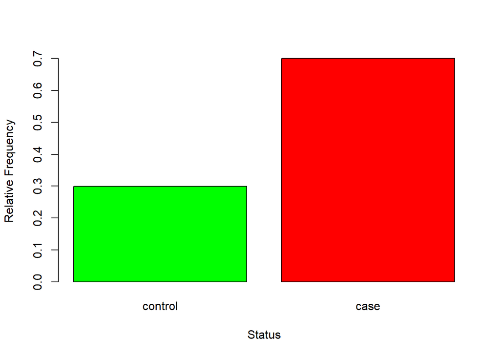

```r
barplot(relfreq.cc, xlab="Status", ylab="Relative Frequency",
        names.arg=c("control", "case"), col=c("green", "red"))
```

## 1.2 The proportion of women and men.

Absolute frequency was obtained, and it was assumed that GENDER had no missing data:

```r
freq.gn<-table(snpdata$GENDER)

freq.gn
```

```
##
## Female   Male
##     82     75
```

Relative frequencies were next obtained:

```r
relfreq.gn<-freq.gn/nrow(snpdata)

relfreq.gn
```

```
##
## Female   Male
## 0.5223 0.4777
```

Relative frequencies were altenernatively obtained as follows:

```r
relfreq.gn<-prop.table(table(snpdata$GENDER))

relfreq.gn
```

```
##
## Female   Male
## 0.5223 0.4777
```

The relative and absolute frequency vector tables were combined into a frequency table and number of table decimal places was set to 4 as follows:

```r
freqtablegn<-cbind(freq.gn, relfreq.gn)
options(digits=4)
freqtablegn
```

```
##        freq.gn relfreq.gn
## Female      82     0.5223
## Male        75     0.4777
```

The relative frequency of Female and Male categorical variables were graphically depicted via a barplot as follows:

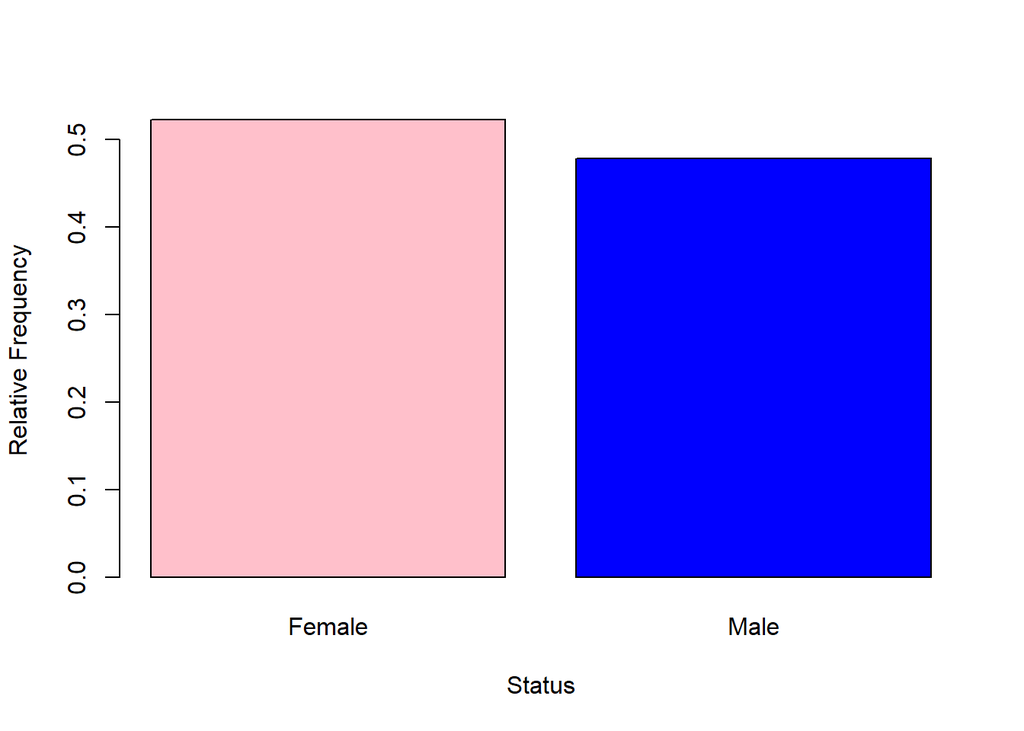

```r
barplot(relfreq.gn, xlab="Status", ylab="Relative Frequency",
        names.arg=c("Female", "Male"), col=c("pink", "blue"))
```

Evidently, the proportion of Female is relatively higher than that of Male.There ratio of females to males is 1.09

## 1.3 The proportion of women and men within cases and controls, respectively:

For absolute frequencies:

```r
table(snpdata$CASECONTROL, snpdata$GENDER)
```

```
##
##           Female Male
##   control     26   21
##   case        56   54
```

For relative frequencies OR total proportions:

```r
prop.table(table(snpdata$CASECONTROL, snpdata$GENDER))
```

```
##
##           Female   Male
##   control 0.1656 0.1338
##   case    0.3567 0.3439
```

The proportion of women and men within cases and controls, respectively, was next depicted graphically in barplot as follows:

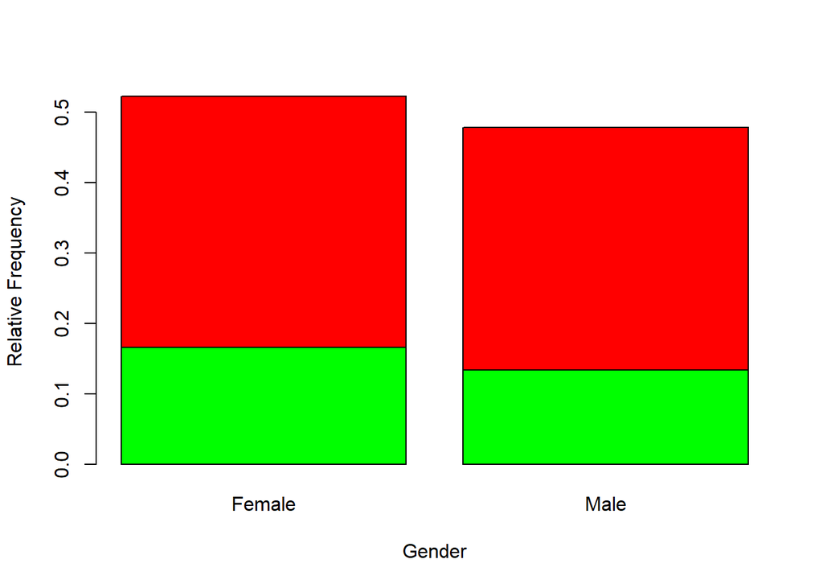

```r
barplot(prop.table(table(snpdata$CASECONTROL, snpdata$GENDER)), xlab="Gender", ylab="Relative Frequency",
        names.arg=c("Female", "Male"), col=c("green", "red"))
```

The proportions of female cases and control were greater than those for male cases and control.

## 1.4 The distribution of the genotypes for each specific SNP when stratifying by sex and by case/control

### 1.4.1 Stratification By Case/Control

For SNP1 when stratifying by case/control with total proportions and missing data excluded:

```r
prop.table(table(snpdata$CASECONTROL, snpdata$SNP1, exclude=NULL))
```

```
##
##                CC      CT      TT
##   control 0.01274 0.13376 0.15287
##   case    0.06369 0.20382 0.43312
```

For SNP1 when stratifying by case/control with columnar proportions and missing data excluded:

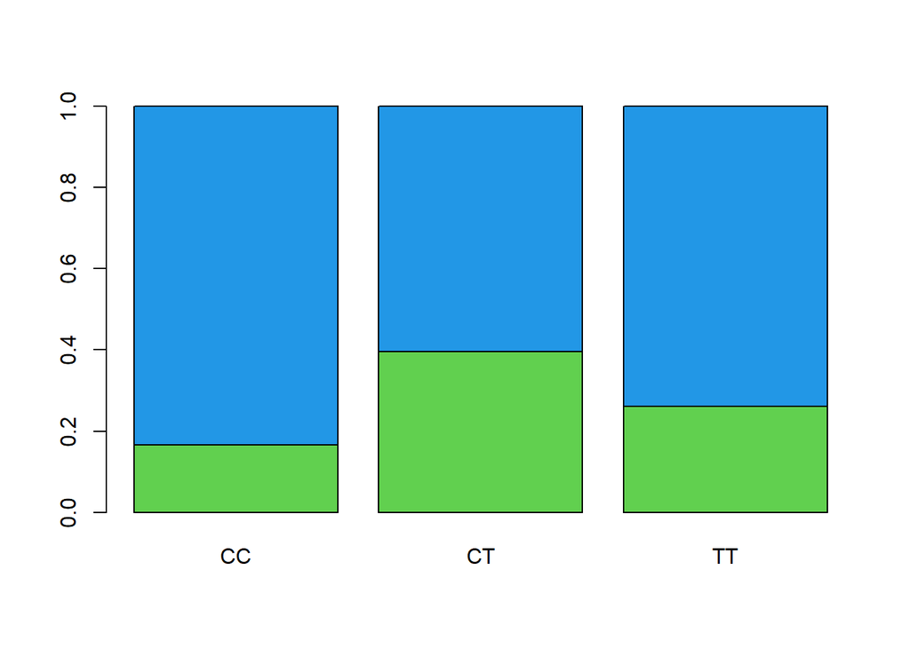

```r
barplot(prop.table(table(snpdata$CASECONTROL, snpdata$SNP1, exclude=NULL),2), col=c(3,4))
```

The ratio of cases to control for the SNP1 CC genotype was the greatest.

```r
prop.table(table(snpdata$CASECONTROL, snpdata$SNP2, exclude=NULL))
```

```
##
##                CC      CG      GG    <NA>
##   control 0.00000 0.12739 0.15924 0.01274
##   case    0.01911 0.30573 0.37580 0.00000
```

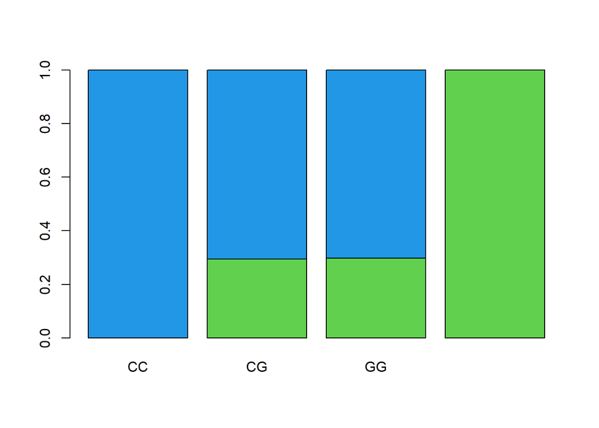

```r
barplot(prop.table(table(snpdata$CASECONTROL, snpdata$SNP2,exclude=NULL),2), col=c(3,4))
```

Interestingly, there were no control results for the SNP2 CC genotype.

```r
prop.table(table(snpdata$CASECONTROL, snpdata$SNP3, exclude=NULL))
```

```
##
##                 AA       AG       GG     <NA>
##   control 0.191083 0.089172 0.012739 0.006369
##   case    0.452229 0.133758 0.044586 0.070064
```

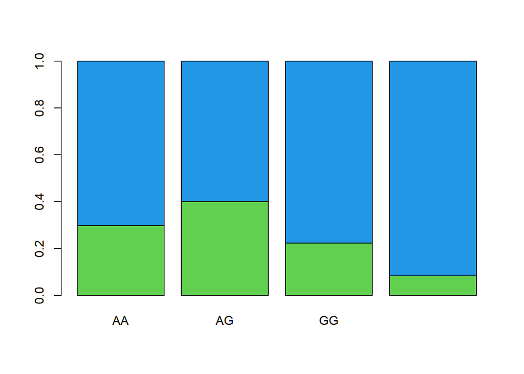

```r
barplot(prop.table(table(snpdata$CASECONTROL, snpdata$SNP3,exclude=NULL),2), col=c(3,4))
```

```r
prop.table(table(snpdata$CASECONTROL, snpdata$SNP4, exclude=NULL))
```

```
##
##                 AA       AC       CC     <NA>
##   control 0.057325 0.114650 0.108280 0.019108
##   case    0.114650 0.356688 0.222930 0.006369
```

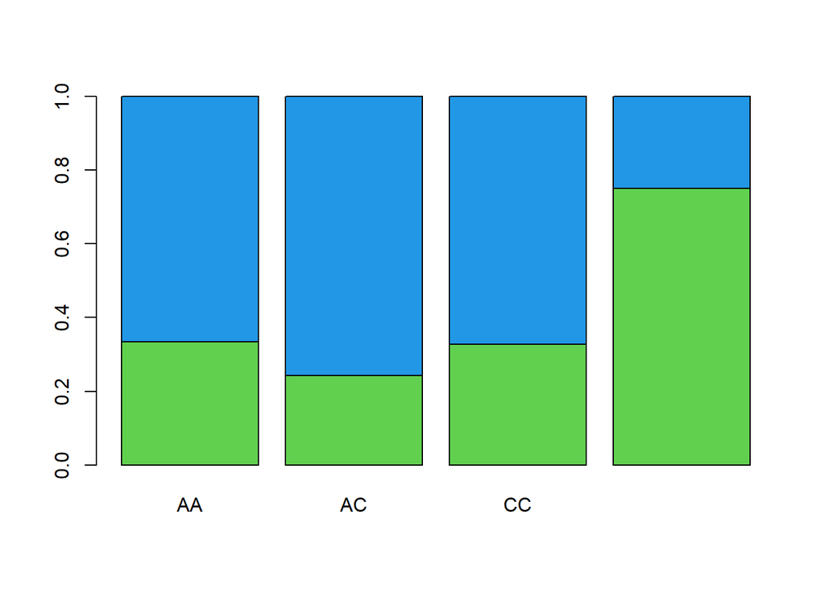

```r
barplot(prop.table(table(snpdata$CASECONTROL, snpdata$SNP4,exclude=NULL),2), col=c(3,4))
```

The ratio of cases to control for SNP4 AC genotype was the highest.

For SNP5 when stratifying by case/control with total proportions and missing data excluded:

```r
prop.table(table(snpdata$CASECONTROL, snpdata$SNP5, exclude=NULL))
```

```
##
##                AA      AC      CC
##   control 0.00000 0.15924 0.14013
##   case    0.03185 0.33758 0.33121
```

For SNP5 when stratifying by case/control with columnar proportions and missing data excluded:

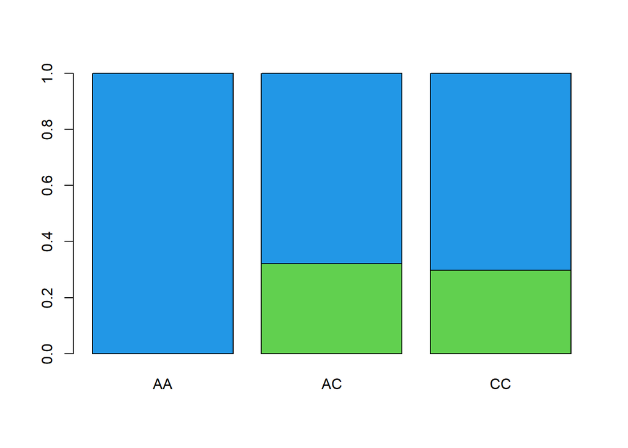

```r
barplot(prop.table(table(snpdata$CASECONTROL, snpdata$SNP5,exclude=NULL),2), col=c(3,4))
```

Interestingly, there were no control results for SNP5 AA genotype

### 1.4.2 Stratification By Sex

For SNP1 when stratifying by Gender with total proportions and missing data excluded:

```r
prop.table(table(snpdata$GENDER, snpdata$SNP1, exclude=NULL))
```

```
##
##               CC      CT      TT
##   Female 0.02548 0.16561 0.33121
##   Male   0.05096 0.17197 0.25478
```

For SNP1 when stratifying by Gender with columnar proportions and missing data excluded:

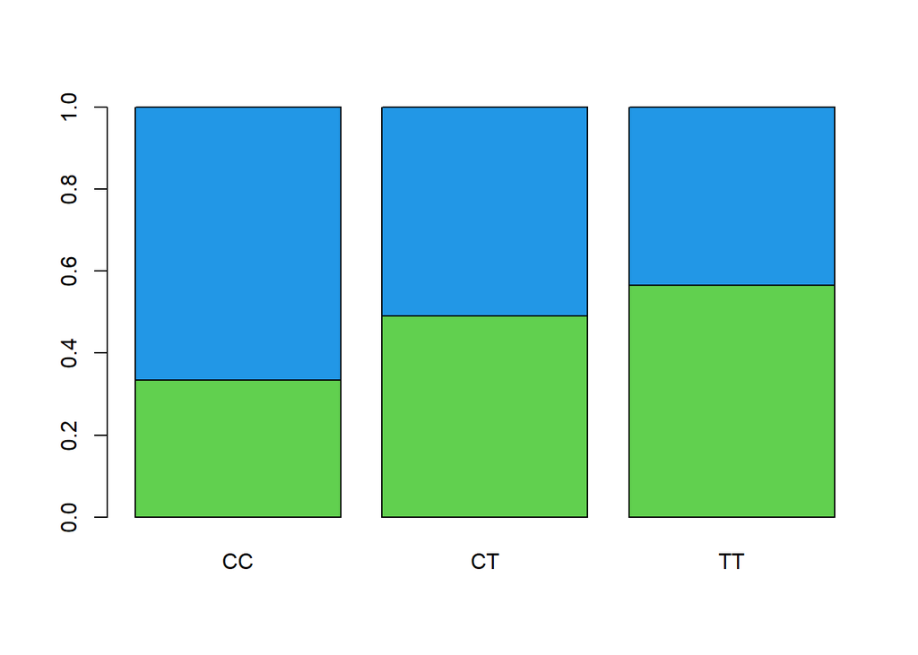

```r
barplot(prop.table(table(snpdata$GENDER, snpdata$SNP1, exclude=NULL),2), col=c(3,4))
```

```r
prop.table(table(snpdata$GENDER, snpdata$SNP2, exclude=NULL))
```

```
##
##                CC       CG       GG     <NA>
##   Female 0.012739 0.261146 0.242038 0.006369
##   Male   0.006369 0.171975 0.292994 0.006369
```

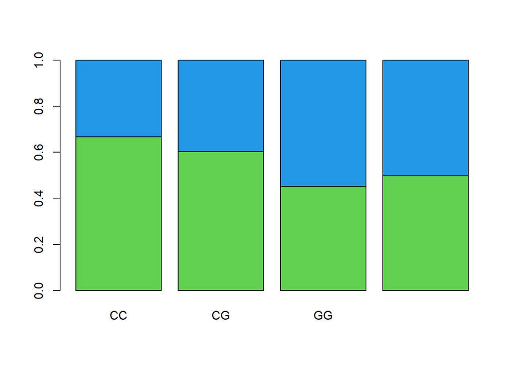

```r
barplot(prop.table(table(snpdata$GENDER, snpdata$SNP2,exclude=NULL),2), col=c(3,4))
```

There was higher ratio of female:male for SNP2 CC genotype than for other genotype

```r
prop.table(table(snpdata$GENDER, snpdata$SNP3, exclude=NULL))
```

```
##
##               AA      AG      GG    <NA>
##   Female 0.36306 0.11465 0.02548 0.01911
##   Male   0.28025 0.10828 0.03185 0.05732
```

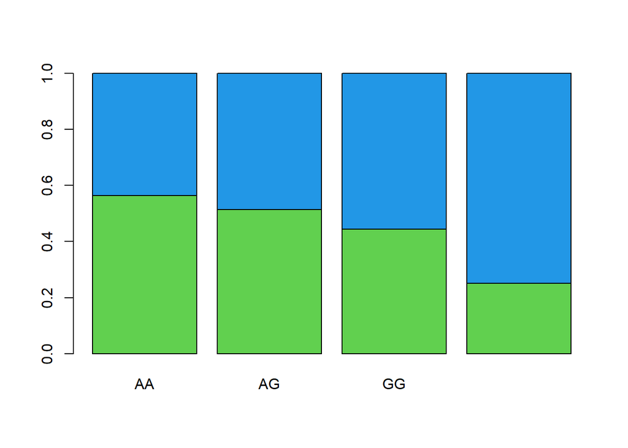

```r
barplot(prop.table(table(snpdata$GENDER, snpdata$SNP3,exclude=NULL),2), col=c(3,4))
```

More females relative to males had SNP3 AA genotype, and more males relative to females had SNP3 GG genotype.

```r
prop.table(table(snpdata$GENDER, snpdata$SNP4, exclude=NULL))
```

```
##
##               AA      AC      CC    <NA>
##   Female 0.08917 0.23567 0.19745 0.00000
##   Male   0.08280 0.23567 0.13376 0.02548
```

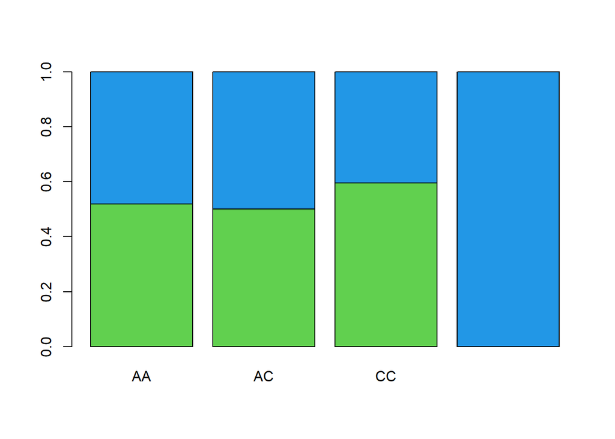

```r
barplot(prop.table(table(snpdata$GENDER, snpdata$SNP4,exclude=NULL),2), col=c(3,4))
```

For SNP5 when stratifying by Gender with total proportions and missing data excluded:

```r
prop.table(table(snpdata$GENDER, snpdata$SNP5, exclude=NULL))
```

```
##
##                AA       AC       CC
##   Female 0.025478 0.305732 0.191083
##   Male   0.006369 0.191083 0.280255
```

For SNP5 when stratifying by Gender with columnar proportions and missing data excluded:

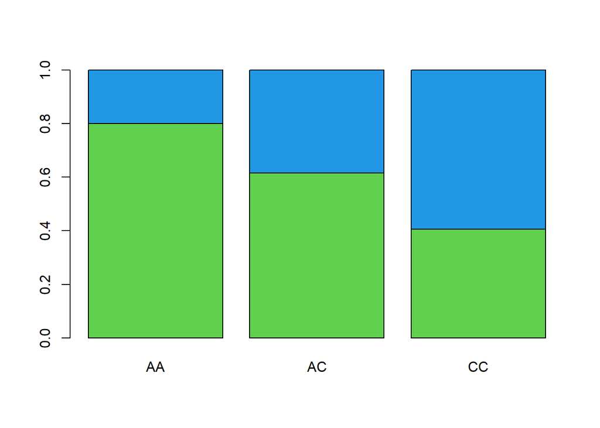

```r
barplot(prop.table(table(snpdata$GENDER, snpdata$SNP5,exclude=NULL),2), col=c(3,4))
```

More females had SNP5 AA genotype compared to male, and more males had SNP5 CC genotype compared to females.

**Boxplot**

A boxplot was used to graphically depict the continuous numerical variable with many values (GENE_EXPRESSON) as follows:

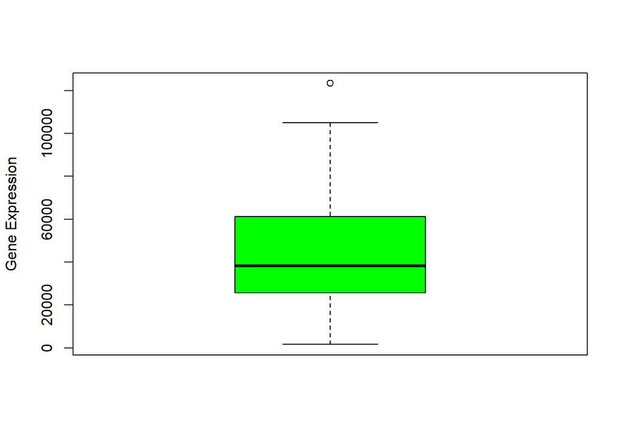

```r
boxplot(snpdata$GENE_EXPRESSION, ylab="Gene Expression", col="green")
```

**Histogram**

A histogram is used to furthermore graphically depict the continuous numerical variable with many values (GENE_EXPRESSON):

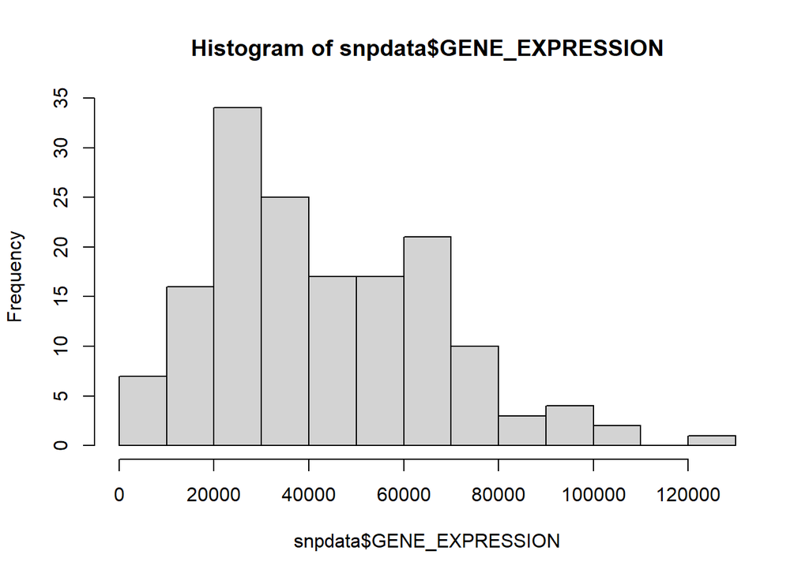

```r
hist(snpdata$GENE_EXPRESSION)
```

**Empirical cumulative distribution**

The empirical cumulative distribution provides the proportion of GENE_EXPRESSION values below a given value:

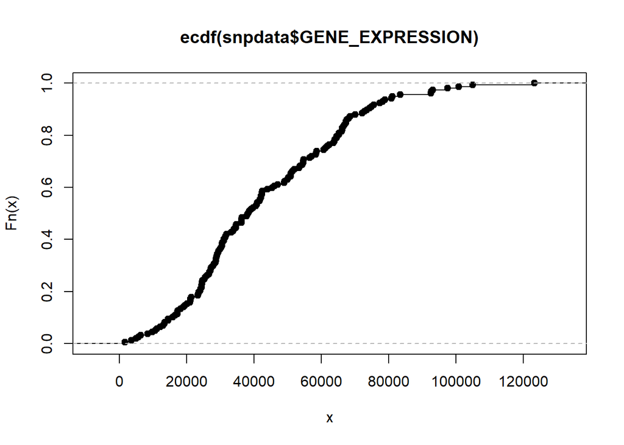

```r
f<-ecdf(snpdata$GENE_EXPRESSION)

plot(f)
```